# PML Project

Patrick Callier

Feb 11 2015

# Loading the data

```r
library(knitr)
opts_chunk$set(message=FALSE,warning=FALSE)

setwd("~/Dropbox/moocs/practical_machine_learning/")
library(ggplot2)
library(plyr)
library(dplyr)
library(reshape2)
library(glmnet)
library(impute)
library(randomForest)
set.seed(219)

# should be in same working directory as data
training <- read.csv("pml-training.csv",row.names=1,na.strings=c("NA","#DIV/0!"),colClasses=c(cvtd_timestamp="character"))
testing <- read.csv("pml-testing.csv",row.names=1,na.strings=c("NA","#DIV/0!"),colClasses=c(cvtd_timestamp="character"))
```

# Preparing the data

A first cleaning step is to remove rows where `new_window` takes the value `yes`. These rows appear to contain some sort of summary data for creating derived features, but since our task (in testing) does not give us data that can be summarized in the same way, these features will not be useful. Dropping these rows now leaves entire variables with only `NA` values, so we drop these as well.

```r
# clean up
training <- transform(training, user_window=as.factor(paste(user_name, num_window)))
training.1 <- filter(training, new_window=="no")
training.1 <- Filter(function(.) { !all(is.na(.)) }, training.1 )

# univariate summary plots
plot.summaries <- function(data, file="summaryplots.pdf") {
  pdf(file, onefile=TRUE)
  for (x in names(data)) {
    if (is.numeric(data[,x])) {
      print(ggplot(aes_string(x=x, fill="classe"), data=data) + geom_histogram() + facet_wrap(~ user_name))
    }
  }
  dev.off()
}
plot.summaries(training.1,'untransformed.pdf')
```

The untransformed variables have some clear flaws, as evidenced in the plot for `magnet_dumbbell_y`, for instance:

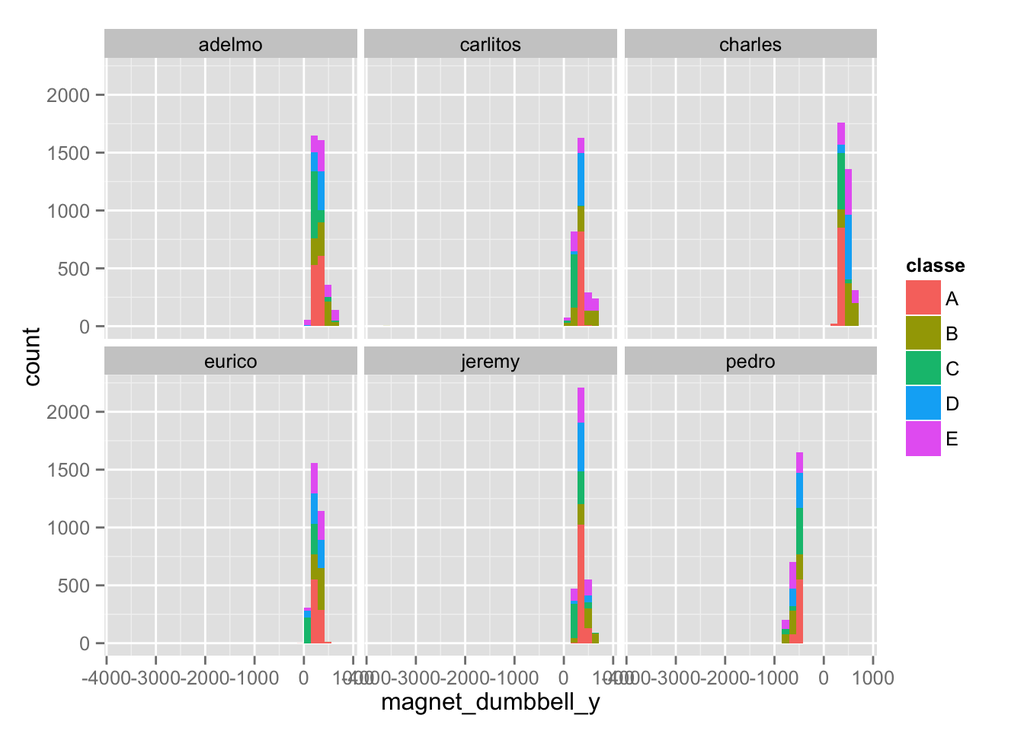

```r
print(ggplot(aes(x=magnet_dumbbell_y, fill=classe), data=training.1) + geom_histogram() + facet_wrap(~ user_name))
```

The majority of values for all users are in a finite, if wide, range, but apparently very sparse extreme values, presumably from sensor malfunctions or other such uninformative processes, jam all the good values into a tiny slice of the dsitribution. In addition, each individual user may have a vastly different mode from the others, which may obscure some of the common structure across users.

The below code generates a list of means and standard deviations for each combination of measurement type (varying first) and user (varying within measurement type), then provides a function `do.transforms` that takes as arguments a daa frame in the shape of our data as well as this list of means and standard deviations. This allows the testing data to be transformed according to the same criteria as the training data. THe transform itself is just a scale and center per user of each variable.

```r
# transform within user for each variable
train.1.pred.indices <- seq(7,58)
# get a list of user-specific means and sds
transformer <- lapply(training.1[,train.1.pred.indices], function(.) {
  return(by(., training.1[,"user_name"], function(x) { list(mu=mean(x), sig=sd(x)) }))
})
do.transforms <- function(data, transformer, trim.outliers=NA) {
  # scale and center data according to a supplied list of means and sds
  # named according to variable and user_name
  for (col in names(transformer)) {
    for (user in names(transformer[[col]])) {
      data[data$user_name==user,col] <- (data[data$user_name==user,col] - transformer[[col]][[user]][["mu"]]) / transformer[[col]][[user]][["sig"]]
    }
  }
  if (!is.na(trim.outliers)) {
    # trim away outliers entirely (deleting the whole observation!)
    slice <- which(apply(data[,names(transformer)], 1, function(.) {any(abs(.) > 5)}))
    data <- data[-slice,]
  }
  return(data)
}
training.2 <- do.transforms(training.1, transformer, 4)
plot.summaries(training.2, "transformed.pdf")
```

```r
# clip off timestamps and windows
training.2 <- select(training.2, -contains("timestamp"), -contains("window"))
```

This improves the situation quite a bit. For comparison, here is the transformed version of `magnet_dumbbell_y`:

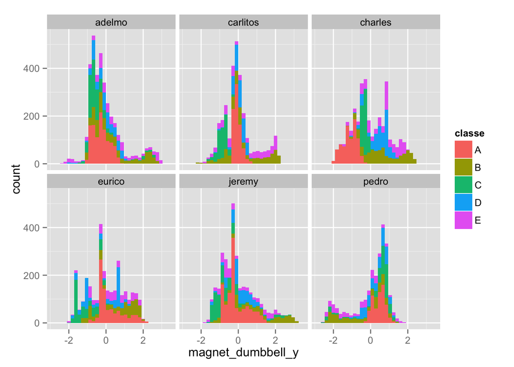

```r
print(ggplot(aes(x=magnet_dumbbell_y, fill=classe), data=training.2) + geom_histogram() + facet_wrap(~ user_name))
```

The transformations are far from perfect. Some variables have a preponderance of zeroes, which are not affected by the scale-and-center, and others have bimodal distributions or other non-normalities which are hard to deal with. So I won’t deal with them.

The transformations above do introduce a new problem though. For completely invariant data ($\sigma$=0), the scaling zaps them into infinity. I will fill in remaining missing values with a k-nearest neighbors imputation, as below.

```r
# do imputation for remaining missings
training.3 <- cbind(training.2[,c(1, 54)], impute.knn(as.matrix(training.2[,names(transformer)]))$data)
```

[output not shown]

```r
plot.summaries(training.3, "imputed.pdf")
```

Finally, we also have to prepare the test data in an analogous fashion to the training data, using the scale-and-center wrapper function defined above and the list of means and standard deviations from the training data. Because the transformation will also do divide-by-zeroes here, I impute again, using the unimputed training data as “neighbors.” This is probably less than optimal, but it works.

```r
# prepare test data, similarly
testing.2 <- testing[,c("user_name", names(transformer))]
testing.2 <- do.transforms(testing.2, transformer)
# impute?!
testing.3 <- cbind(user_name=testing[,"user_name"], as.data.frame(impute.knn(as.matrix(rbind(testing.2[,names(transformer)], training.2[,names(transformer)])))$data)[1:20,])
```

[output not shown]

# Analysis

A completely naive use-largest-category classification strategy would yield a fairly low baseline correct classification rate: 28.8077336% (classifying to A).

## Binary logistic regression

I think even a completely dumb model can do way better, so I’m going to try a binary logistic regression, just as a first pass. This is doing a slightly different task than the one we’re supposed to be doing, since the not-A category lumps together four factor levels, but since A represents ‘success,’ this is still a potentially interesting model. I don’t do cross-validation or regularization or what-have-you since I’m not actually planning to use this model for prediction.

```r
# binary logistic regression (A vs not-A)
bar.glm <- glm(classe=="A" ~ ., family=binomial(), data=training.3)
isc <- table(predict(bar.glm, type="link") > 0, training.3$classe=="A")
print(isc)
```

```
##
##         FALSE  TRUE
##   FALSE 12385  1017
##   TRUE    871  4347
```

```r
# Overall in-sample correct classification rate
sum(diag(isc))/sum(isc)
```

```
## [1] 0.8986037
```

## Multinomial regression

Still, binomial logistic regression’s error rate isn’t great. Generalizing to a multinomial logistic regression using 10-fold cross validation from glmnet, we get an even higher in-sample error rate than the binary logistic regression for the simplified problem.

```r
# multinomial regression
data.samp.y <- training.3[,"classe"]
data.samp.x <- as.matrix(select(training.3, -contains("classe"), -contains("user_name")))
bar.multi.glmnet <- cv.glmnet(x=data.samp.x, y=data.samp.y, family="multinomial")

bmg.pred <- predict(bar.multi.glmnet, data.samp.x)
bmg.pred.class <- c("A","B","C","D","E")[apply(bmg.pred, 1, which.max)]
# in sample confusion
isc <- table(bmg.pred.class, data.samp.y)
print(isc)
```

```
##               data.samp.y
## bmg.pred.class    A    B    C    D    E
##              A 4683  496  371  263   83
##              B  209 2435  267   78  331
##              C  151  399 2460  411  184
##              D  284  112  190 2234  283
##              E   37  226   61  148 2224
```

```r
# Overall in-sample correct classification rate
sum(diag(isc))/sum(isc)
```

```
## [1] 0.7538131
```

## Random forests

Since multinomial regression is not very good either, let’s try random forests, since those are supposed to be awesome. Because of the way random forests are grown (using iterative testing on out-of-bag samples), cross-validation is not necessary.

```r
# random forests
har.ranfor <- randomForest(classe ~ ., data=training.3)
har.rf.pred <- predict(har.ranfor)
isc <- table(har.rf.pred, training.3$classe)
print(isc)
```

```
##
## har.rf.pred    A    B    C    D    E
##           A 5361   10    0    0    0
##           B    2 3654   19    0    1
##           C    0    4 3327   34    4
##           D    1    0    3 3099    6
##           E    0    0    0    1 3094
```

```r
# Overall in-sample correct classification rate
sum(diag(isc))/sum(isc)
```

```
## [1] 0.995435
```

```r
# "Out-of-bag" error rate: estimation of out-of-sample error rate,
# using all the trees grown in the forest
print(1-har.ranfor$err.rate[length(har.ranfor$err.rate)])
```

```
## [1] 0.9964573
```

```r
answers <- as.character(predict(har.ranfor, testing.3))
#print(answers)

# submission
pml_write_files = function(x){
  n = length(x)
  for(i in 1:n){
    filename = paste0("problem_id_",i,".txt")
    write.table(x[i],file=filename,quote=FALSE,row.names=FALSE,col.names=FALSE)
  }
}

pml_write_files(answers)
```